# ANCOVA in flow (debate) (flow (debate))

Geiser C. Challco geiser@alumni.usp.br

- Descriptive Statistics of Initial Data
- ANCOVA and Pairwise for one factor: **grupo**
  - Without remove non-normal data
  - Computing ANCOVA and PairWise After removing non-normal data (OK)
    - Plots for ancova
    - Checking linearity assumption
    - Checking normality and homogeneity
- ANCOVA and Pairwise for two factors **grupo:Sexo**
  - Without remove non-normal data
  - Computing ANCOVA and PairWise After removing non-normal data (OK)
    - Plots for ancova
    - Checking linearity assumption
    - Checking normality and homogeneity
- ANCOVA and Pairwise for two factors **grupo:Zona**
  - Without remove non-normal data
  - Computing ANCOVA and PairWise After removing non-normal data (OK)
    - Plots for ancova
    - Checking linearity assumption
    - Checking normality and homogeneity
- ANCOVA and Pairwise for two factors **grupo:Cor.Raca**
  - Without remove non-normal data
  - Computing ANCOVA and PairWise After removing non-normal data (OK)
    - Plots for ancova
    - Checking linearity assumption
    - Checking normality and homogeneity
- Summary of Results
  - Descriptive Statistics
  - ANCOVA Table Comparison
  - PairWise Table Comparison
  - EMMS Table Comparison

**NOTE**:

- Teste ANCOVA para determinar se houve diferenças significativas no flow (debate) (medido usando pre- e pos-testes).
- ANCOVA test to determine whether there were significant differences in flow (debate) (measured using pre- and post-tests).

# Descriptive Statistics of Initial Data

```r
df <- get.descriptives(dat, c(dv.pre, dv.pos), c("grupo"),
                       include.global = T, symmetry.test = T, normality.test = F)
df <- plyr::rbind.fill(
  df, do.call(plyr::rbind.fill, lapply(lfatores2, FUN = function(f) {
    if (nrow(dat) > 0 && sum(!is.na(unique(dat[[f]]))) > 1)
      get.descriptives(dat, c(dv.pre,dv.pos), c("grupo", f),
                       symmetry.test = T, normality.test = F)
    }))
)
(df <- df[,c(fatores1[fatores1 %in% colnames(df)],"variable",
             colnames(df)[!colnames(df) %in% c(fatores1,"variable")])])
```

```
##           grupo Sexo   Zona Cor.Raca        variable   n  mean median   min   max    sd    se    ci   iqr
## 1      Controle <NA>   <NA>     <NA> dfs.media.debat 123 3.404  3.444 1.889 4.889 0.584 0.053 0.104 0.778
## 2  Experimental <NA>   <NA>     <NA> dfs.media.debat 177 3.463  3.444 1.333 4.667 0.566 0.043 0.084 0.778
## 3          <NA> <NA>   <NA>     <NA> dfs.media.debat 300 3.439  3.444 1.333 4.889 0.573 0.033 0.065 0.778
## 4      Controle <NA>   <NA>     <NA> fss.media.debat 123 3.374  3.444 2.111 4.556 0.526 0.047 0.094 0.778
## 5  Experimental <NA>   <NA>     <NA> fss.media.debat 177 3.551  3.556 1.778 5.000 0.591 0.044 0.088 0.778
## 6          <NA> <NA>   <NA>     <NA> fss.media.debat 300 3.478  3.444 1.778 5.000 0.571 0.033 0.065 0.889
## 7      Controle    F   <NA>     <NA> dfs.media.debat  67 3.495  3.556 2.333 4.889 0.520 0.064 0.127 0.667
## 8      Controle    M   <NA>     <NA> dfs.media.debat  56 3.294  3.333 1.889 4.556 0.639 0.085 0.171 0.833
## 9  Experimental    F   <NA>     <NA> dfs.media.debat  83 3.475  3.444 2.222 4.556 0.526 0.058 0.115 0.667
## 10 Experimental    M   <NA>     <NA> dfs.media.debat  94 3.452  3.444 1.333 4.667 0.602 0.062 0.123 0.778
## 11     Controle    F   <NA>     <NA> fss.media.debat  67 3.426  3.444 2.333 4.556 0.508 0.062 0.124 0.882
## 12     Controle    M   <NA>     <NA> fss.media.debat  56 3.311  3.437 2.111 4.444 0.544 0.073 0.146 0.694
## 13 Experimental    F   <NA>     <NA> fss.media.debat  83 3.519  3.556 1.778 5.000 0.605 0.066 0.132 0.833
## 14 Experimental    M   <NA>     <NA> fss.media.debat  94 3.578  3.556 2.222 5.000 0.579 0.060 0.119 0.667
```

[output cut: 67 more lines]

| grupo | Sexo | Zona | Cor.Raca | variable | n | mean | median | min | max | sd | se | ci | iqr | symmetry | skewness | kurtosis |
| --- | --- | --- | --- | --- | --- | --- | --- | --- | --- | --- | --- | --- | --- | --- | --- | --- |
| Controle |  |  |  | dfs.media.debat | 123 | 3.404 | 3.444 | 1.889 | 4.889 | 0.584 | 0.053 | 0.104 | 0.778 | YES | -0.067 | -0.370 |
| Experimental |  |  |  | dfs.media.debat | 177 | 3.463 | 3.444 | 1.333 | 4.667 | 0.566 | 0.043 | 0.084 | 0.778 | YES | -0.379 | 0.470 |
|  |  |  |  | dfs.media.debat | 300 | 3.439 | 3.444 | 1.333 | 4.889 | 0.573 | 0.033 | 0.065 | 0.778 | YES | -0.249 | 0.095 |
| Controle |  |  |  | fss.media.debat | 123 | 3.374 | 3.444 | 2.111 | 4.556 | 0.526 | 0.047 | 0.094 | 0.778 | YES | -0.189 | -0.507 |
| Experimental |  |  |  | fss.media.debat | 177 | 3.551 | 3.556 | 1.778 | 5.000 | 0.591 | 0.044 | 0.088 | 0.778 | YES | 0.114 | 0.253 |
|  |  |  |  | fss.media.debat | 300 | 3.478 | 3.444 | 1.778 | 5.000 | 0.571 | 0.033 | 0.065 | 0.889 | YES | 0.063 | 0.151 |
| Controle | F |  |  | dfs.media.debat | 67 | 3.495 | 3.556 | 2.333 | 4.889 | 0.520 | 0.064 | 0.127 | 0.667 | YES | 0.114 | -0.128 |
| Controle | M |  |  | dfs.media.debat | 56 | 3.294 | 3.333 | 1.889 | 4.556 | 0.639 | 0.085 | 0.171 | 0.833 | YES | -0.016 | -0.814 |
| Experimental | F |  |  | dfs.media.debat | 83 | 3.475 | 3.444 | 2.222 | 4.556 | 0.526 | 0.058 | 0.115 | 0.667 | YES | -0.098 | -0.349 |
| Experimental | M |  |  | dfs.media.debat | 94 | 3.452 | 3.444 | 1.333 | 4.667 | 0.602 | 0.062 | 0.123 | 0.778 | NO | -0.524 | 0.715 |
| Controle | F |  |  | fss.media.debat | 67 | 3.426 | 3.444 | 2.333 | 4.556 | 0.508 | 0.062 | 0.124 | 0.882 | YES | -0.077 | -0.882 |
| Controle | M |  |  | fss.media.debat | 56 | 3.311 | 3.437 | 2.111 | 4.444 | 0.544 | 0.073 | 0.146 | 0.694 | YES | -0.257 | -0.378 |
| Experimental | F |  |  | fss.media.debat | 83 | 3.519 | 3.556 | 1.778 | 5.000 | 0.605 | 0.066 | 0.132 | 0.833 | YES | -0.156 | 0.200 |
| Experimental | M |  |  | fss.media.debat | 94 | 3.578 | 3.556 | 2.222 | 5.000 | 0.579 | 0.060 | 0.119 | 0.667 | YES | 0.397 | 0.113 |
| Controle |  | Rural |  | dfs.media.debat | 53 | 3.491 | 3.556 | 2.444 | 4.889 | 0.483 | 0.066 | 0.133 | 0.667 | YES | 0.352 | 0.280 |
| Controle |  | Urbana |  | dfs.media.debat | 54 | 3.346 | 3.333 | 1.889 | 4.667 | 0.630 | 0.086 | 0.172 | 0.889 | YES | -0.181 | -0.649 |
| Controle |  |  |  | dfs.media.debat | 16 | 3.309 | 3.111 | 2.333 | 4.444 | 0.714 | 0.178 | 0.380 | 1.299 | YES | 0.231 | -1.594 |
| Experimental |  | Rural |  | dfs.media.debat | 75 | 3.474 | 3.444 | 1.333 | 4.667 | 0.616 | 0.071 | 0.142 | 0.778 | NO | -0.565 | 0.919 |
| Experimental |  | Urbana |  | dfs.media.debat | 76 | 3.487 | 3.444 | 2.333 | 4.667 | 0.487 | 0.056 | 0.111 | 0.608 | YES | 0.055 | -0.440 |
| Experimental |  |  |  | dfs.media.debat | 26 | 3.359 | 3.444 | 2.000 | 4.333 | 0.637 | 0.125 | 0.257 | 1.000 | YES | -0.267 | -0.991 |
| Controle |  | Rural |  | fss.media.debat | 53 | 3.401 | 3.444 | 2.333 | 4.333 | 0.462 | 0.064 | 0.127 | 0.778 | YES | -0.294 | -0.853 |
| Controle |  | Urbana |  | fss.media.debat | 54 | 3.376 | 3.389 | 2.111 | 4.556 | 0.590 | 0.080 | 0.161 | 0.889 | YES | -0.174 | -0.683 |
| Controle |  |  |  | fss.media.debat | 16 | 3.277 | 3.325 | 2.222 | 4.222 | 0.513 | 0.128 | 0.273 | 0.472 | YES | 0.104 | -0.264 |
| Experimental |  | Rural |  | fss.media.debat | 75 | 3.517 | 3.444 | 1.778 | 5.000 | 0.563 | 0.065 | 0.130 | 0.771 | YES | 0.196 | 0.782 |
| Experimental |  | Urbana |  | fss.media.debat | 76 | 3.572 | 3.556 | 2.111 | 5.000 | 0.620 | 0.071 | 0.142 | 0.889 | YES | 0.168 | -0.187 |
| Experimental |  |  |  | fss.media.debat | 26 | 3.586 | 3.556 | 2.222 | 4.889 | 0.600 | 0.118 | 0.242 | 0.639 | YES | -0.344 | 0.014 |
| Controle |  |  | Branca | dfs.media.debat | 17 | 3.333 | 3.111 | 2.111 | 4.889 | 0.716 | 0.174 | 0.368 | 0.889 | YES | 0.209 | -0.654 |
| Controle |  |  | Indígena | dfs.media.debat | 4 | 3.833 | 3.889 | 3.667 | 3.889 | 0.111 | 0.056 | 0.177 | 0.056 | few data | 0.000 | 0.000 |
| Controle |  |  | Parda | dfs.media.debat | 41 | 3.407 | 3.333 | 1.889 | 4.667 | 0.564 | 0.088 | 0.178 | 0.667 | YES | -0.125 | 0.006 |
| Controle |  |  |  | dfs.media.debat | 61 | 3.393 | 3.444 | 2.250 | 4.556 | 0.574 | 0.073 | 0.147 | 0.750 | YES | -0.011 | -0.806 |
| Experimental |  |  | Branca | dfs.media.debat | 11 | 3.465 | 3.444 | 2.333 | 4.222 | 0.566 | 0.171 | 0.380 | 0.778 | YES | -0.492 | -0.979 |
| Experimental |  |  | Parda | dfs.media.debat | 43 | 3.428 | 3.333 | 1.333 | 4.667 | 0.630 | 0.096 | 0.194 | 0.778 | NO | -0.632 | 1.206 |
| Experimental |  |  |  | dfs.media.debat | 123 | 3.475 | 3.444 | 2.000 | 4.667 | 0.547 | 0.049 | 0.098 | 0.771 | YES | -0.198 | -0.140 |
| Controle |  |  | Branca | fss.media.debat | 17 | 3.366 | 3.111 | 2.556 | 4.333 | 0.535 | 0.130 | 0.275 | 0.889 | YES | 0.445 | -1.305 |
| Controle |  |  | Indígena | fss.media.debat | 4 | 3.833 | 3.889 | 3.556 | 4.000 | 0.192 | 0.096 | 0.306 | 0.111 | few data | 0.000 | 0.000 |
| Controle |  |  | Parda | fss.media.debat | 41 | 3.384 | 3.444 | 2.222 | 4.556 | 0.545 | 0.085 | 0.172 | 0.667 | YES | -0.086 | -0.500 |
| Controle |  |  |  | fss.media.debat | 61 | 3.339 | 3.429 | 2.111 | 4.333 | 0.520 | 0.067 | 0.133 | 0.778 | YES | -0.357 | -0.481 |
| Experimental |  |  | Branca | fss.media.debat | 11 | 3.352 | 3.333 | 2.222 | 4.333 | 0.642 | 0.194 | 0.431 | 0.889 | YES | -0.232 | -1.279 |
| Experimental |  |  | Parda | fss.media.debat | 43 | 3.572 | 3.500 | 2.778 | 5.000 | 0.579 | 0.088 | 0.178 | 0.722 | NO | 0.820 | -0.001 |
| Experimental |  |  |  | fss.media.debat | 123 | 3.561 | 3.556 | 1.778 | 5.000 | 0.592 | 0.053 | 0.106 | 0.778 | YES | -0.067 | 0.332 |

# ANCOVA and Pairwise for one factor: **grupo**

## Without remove non-normal data

```r
pdat = remove_group_data(dat[!is.na(dat[["grupo"]]),], "fss.media.debat", "grupo")

pdat.long <- rbind(pdat[,c("id","grupo")], pdat[,c("id","grupo")])
pdat.long[["time"]] <- c(rep("pre", nrow(pdat)), rep("pos", nrow(pdat)))
pdat.long[["time"]] <- factor(pdat.long[["time"]], c("pre","pos"))
pdat.long[["flow.debat"]] <- c(pdat[["dfs.media.debat"]], pdat[["fss.media.debat"]])

aov = anova_test(pdat, fss.media.debat ~ dfs.media.debat + grupo)
laov[["grupo"]] <- get_anova_table(aov)
```

```r
pwc <- emmeans_test(pdat, fss.media.debat ~ grupo, covariate = dfs.media.debat,
                    p.adjust.method = "bonferroni")
```

```r
pwc.long <- emmeans_test(dplyr::group_by_at(pdat.long, "grupo"),
                          flow.debat ~ time,
                          p.adjust.method = "bonferroni")
lpwc[["grupo"]] <- plyr::rbind.fill(pwc, pwc.long)
```

```r
ds <- get.descriptives(pdat, "fss.media.debat", "grupo", covar = "dfs.media.debat")
ds <- merge(ds[ds$variable != "dfs.media.debat",],
            ds[ds$variable == "dfs.media.debat", !colnames(ds) %in% c("variable")],
            by = "grupo", all.x = T, suffixes = c("", ".dfs.media.debat"))
ds <- merge(get_emmeans(pwc), ds, by = "grupo", suffixes = c(".emms", ""))
ds <- ds[,c("grupo","n","mean.dfs.media.debat","se.dfs.media.debat","mean","se","emmean","se.emms")]

colnames(ds) <- c("grupo", "N", paste0(c("M","SE")," (pre)"),
                  paste0(c("M","SE"), " (unadj)"), paste0(c("M", "SE"), " (adj)"))

lemms[["grupo"]] <- ds
```

## Computing ANCOVA and PairWise After removing non-normal data (OK)

```r
wdat = pdat

res = residuals(lm(fss.media.debat ~ dfs.media.debat + grupo, data = wdat))
non.normal = getNonNormal(res, wdat$id, plimit = 0.05)

wdat = wdat[!wdat$id %in% non.normal,]

wdat.long <- rbind(wdat[,c("id","grupo")], wdat[,c("id","grupo")])
wdat.long[["time"]] <- c(rep("pre", nrow(wdat)), rep("pos", nrow(wdat)))
wdat.long[["time"]] <- factor(wdat.long[["time"]], c("pre","pos"))
wdat.long[["flow.debat"]] <- c(wdat[["dfs.media.debat"]], wdat[["fss.media.debat"]])

ldat[["grupo"]] = wdat

(non.normal)
```

```r
aov = anova_test(wdat, fss.media.debat ~ dfs.media.debat + grupo)
laov[["grupo"]] <- merge(get_anova_table(aov), laov[["grupo"]], by="Effect", suffixes = c("","'"))

(df = get_anova_table(aov))
```

```
## ANOVA Table (type II tests)
##
##            Effect DFn DFd      F       p p<.05   ges
## 1 dfs.media.debat   1 297 43.018 2.4e-10     * 0.127
## 2           grupo   1 297  6.324 1.2e-02     * 0.021
```

| Effect | DFn | DFd | F | p | p<.05 | ges |
| --- | --- | --- | --- | --- | --- | --- |
| dfs.media.debat | 1 | 297 | 43.018 | 0.000 | * | 0.127 |
| grupo | 1 | 297 | 6.324 | 0.012 | * | 0.021 |

| term | .y. | group1 | group2 | df | statistic | p | p.adj | p.adj.signif |
| --- | --- | --- | --- | --- | --- | --- | --- | --- |
| dfs.media.debat*grupo | fss.media.debat | Controle | Experimental | 297 | -2.515 | 0.012 | 0.012 | * |

```r
pwc.long <- emmeans_test(dplyr::group_by_at(wdat.long, "grupo"),
                         flow.debat ~ time,
                         p.adjust.method = "bonferroni")
lpwc[["grupo"]] <- merge(plyr::rbind.fill(pwc, pwc.long), lpwc[["grupo"]], by=c("grupo","term",".y.","group1","group2"), suffixes = c("","'"))
```

| grupo | term | .y. | group1 | group2 | df | statistic | p | p.adj | p.adj.signif |
| --- | --- | --- | --- | --- | --- | --- | --- | --- | --- |
| Controle | time | flow.debat | pre | pos | 596 | 0.416 | 0.678 | 0.678 | ns |
| Experimental | time | flow.debat | pre | pos | 596 | -1.453 | 0.147 | 0.147 | ns |

```r
ds <- get.descriptives(wdat, "fss.media.debat", "grupo", covar = "dfs.media.debat")
ds <- merge(ds[ds$variable != "dfs.media.debat",],
            ds[ds$variable == "dfs.media.debat", !colnames(ds) %in% c("variable")],
            by = "grupo", all.x = T, suffixes = c("", ".dfs.media.debat"))
ds <- merge(get_emmeans(pwc), ds, by = "grupo", suffixes = c(".emms", ""))
ds <- ds[,c("grupo","n","mean.dfs.media.debat","se.dfs.media.debat","mean","se","emmean","se.emms")]

colnames(ds) <- c("grupo", "N", paste0(c("M","SE")," (pre)"),
                  paste0(c("M","SE"), " (unadj)"), paste0(c("M", "SE"), " (adj)"))

lemms[["grupo"]] <- merge(ds, lemms[["grupo"]], by=c("grupo"), suffixes = c("","'"))
```

| grupo | N | M (pre) | SE (pre) | M (unadj) | SE (unadj) | M (adj) | SE (adj) |
| --- | --- | --- | --- | --- | --- | --- | --- |
| Controle | 123 | 3.404 | 0.053 | 3.374 | 0.047 | 3.386 | 0.048 |
| Experimental | 177 | 3.463 | 0.043 | 3.551 | 0.044 | 3.542 | 0.040 |

### Plots for ancova

```r
plots <- oneWayAncovaPlots(
  wdat, "fss.media.debat", "grupo", aov, list("grupo"=pwc), addParam = c("mean_se"),
  font.label.size=10, step.increase=0.05, p.label="p.adj",
  subtitle = which(aov$Effect == "grupo"))
```

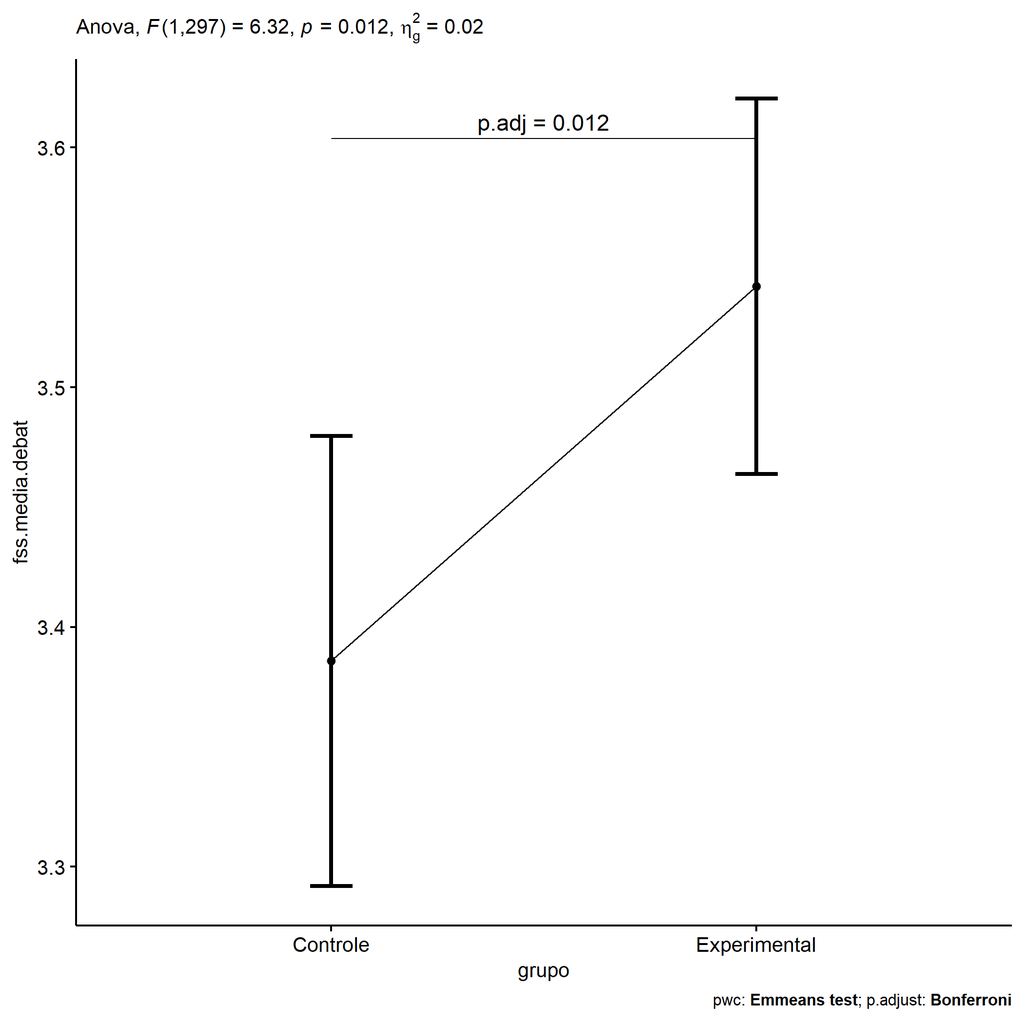

```r
if (!is.null(nrow(plots[["grupo"]]$data)))
  plots[["grupo"]] + ggplot2::scale_color_manual(values = color[["grupo"]])
```

```r
plots <- oneWayAncovaBoxPlots(
  wdat, "fss.media.debat", "grupo", aov, pwc, covar = "dfs.media.debat",
  theme = "classic", color = color[["grupo"]],
  subtitle = which(aov$Effect == "grupo"))
```

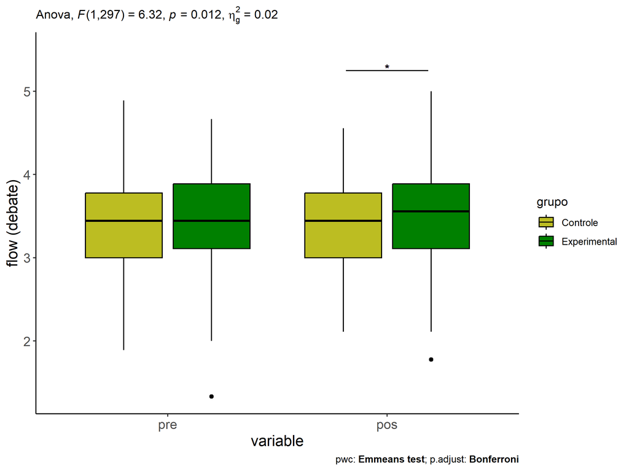

```r
if (length(unique(wdat[["grupo"]])) > 1)
  plots[["grupo"]] + ggplot2::ylab("flow (debate)") + ggplot2::scale_x_discrete(labels=c('pre', 'pos'))
```

```r
if (length(unique(wdat.long[["grupo"]])) > 1)
  plots <- oneWayAncovaBoxPlots(
    wdat.long, "flow.debat", "grupo", aov, pwc.long, pre.post = "time",
    theme = "classic", color = color$prepost)
```

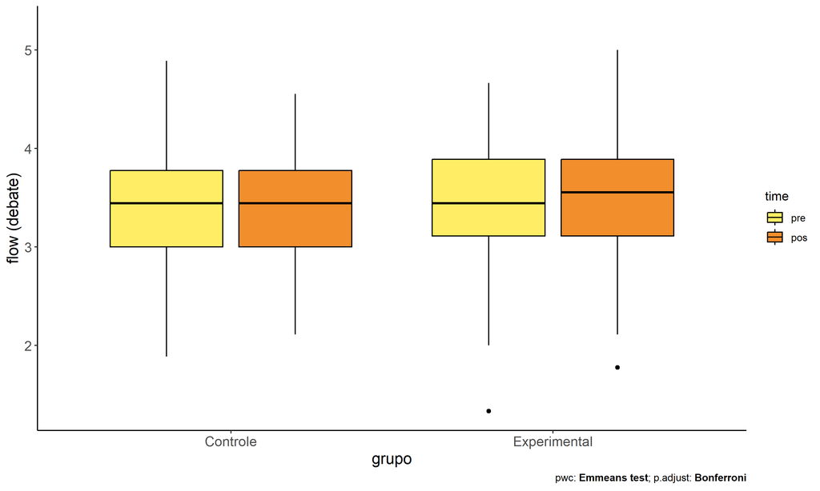

```r
if (length(unique(wdat.long[["grupo"]])) > 1)
  plots[["grupo"]] + ggplot2::ylab("flow (debate)")
```

### Checking linearity assumption

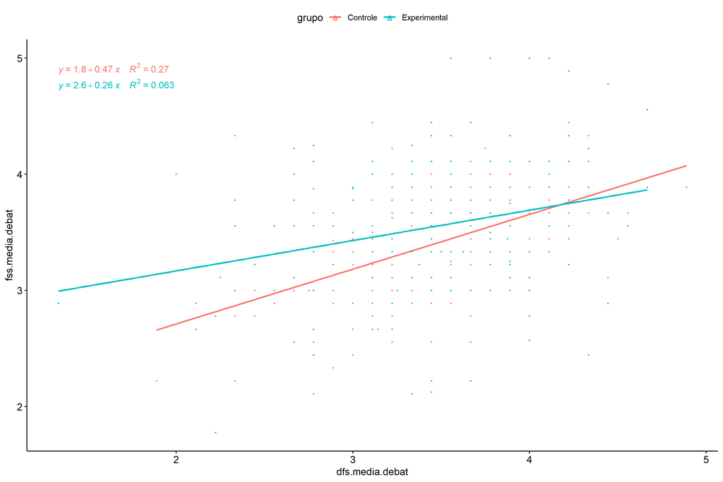

```r
ggscatter(wdat, x = "dfs.media.debat", y = "fss.media.debat", size = 0.5,
          color = "grupo", add = "reg.line")+
  stat_regline_equation(
    aes(label =  paste(..eq.label.., ..rr.label.., sep = "~~~~"), color = grupo)
  )
```

### Checking normality and homogeneity

```r
res <- augment(lm(fss.media.debat ~ dfs.media.debat + grupo, data = wdat))
```

```r
shapiro_test(res$.resid)
```

```
## # A tibble: 1 × 3
##   variable   statistic p.value
##   <chr>          <dbl>   <dbl>
## 1 res$.resid     0.995   0.476
```

```r
levene_test(res, .resid ~ grupo)
```

```
## # A tibble: 1 × 4
##     df1   df2 statistic      p
##   <int> <int>     <dbl>  <dbl>
## 1     1   298      6.22 0.0132
```

# ANCOVA and Pairwise for two factors **grupo:Sexo**

## Without remove non-normal data

```r
pdat = remove_group_data(dat[!is.na(dat[["grupo"]]) & !is.na(dat[["Sexo"]]),], "fss.media.debat", c("grupo","Sexo"))

pdat.long <- rbind(pdat[,c("id","grupo","Sexo")], pdat[,c("id","grupo","Sexo")])
pdat.long[["time"]] <- c(rep("pre", nrow(pdat)), rep("pos", nrow(pdat)))
pdat.long[["time"]] <- factor(pdat.long[["time"]], c("pre","pos"))
pdat.long[["flow.debat"]] <- c(pdat[["dfs.media.debat"]], pdat[["fss.media.debat"]])

aov = anova_test(pdat, fss.media.debat ~ dfs.media.debat + grupo*Sexo)
laov[["grupo:Sexo"]] <- get_anova_table(aov)
```

```r
pwcs <- list()
pwcs[["Sexo"]] <- emmeans_test(
  group_by(pdat, grupo), fss.media.debat ~ Sexo,
  covariate = dfs.media.debat, p.adjust.method = "bonferroni")
pwcs[["grupo"]] <- emmeans_test(
  group_by(pdat, Sexo), fss.media.debat ~ grupo,
  covariate = dfs.media.debat, p.adjust.method = "bonferroni")

pwc <- plyr::rbind.fill(pwcs[["grupo"]], pwcs[["Sexo"]])
pwc <- pwc[,c("grupo","Sexo", colnames(pwc)[!colnames(pwc) %in% c("grupo","Sexo")])]
```

```r
pwc.long <- emmeans_test(dplyr::group_by_at(pdat.long, c("grupo","Sexo")),
                         flow.debat ~ time,
                         p.adjust.method = "bonferroni")
lpwc[["grupo:Sexo"]] <- plyr::rbind.fill(pwc, pwc.long)
```

```r
ds <- get.descriptives(pdat, "fss.media.debat", c("grupo","Sexo"), covar = "dfs.media.debat")
ds <- merge(ds[ds$variable != "dfs.media.debat",],
            ds[ds$variable == "dfs.media.debat", !colnames(ds) %in% c("variable")],
            by = c("grupo","Sexo"), all.x = T, suffixes = c("", ".dfs.media.debat"))
ds <- merge(get_emmeans(pwcs[["grupo"]]), ds, by = c("grupo","Sexo"), suffixes = c(".emms", ""))
ds <- ds[,c("grupo","Sexo","n","mean.dfs.media.debat","se.dfs.media.debat","mean","se","emmean","se.emms")]

colnames(ds) <- c("grupo","Sexo", "N", paste0(c("M","SE")," (pre)"),
                  paste0(c("M","SE"), " (unadj)"), paste0(c("M", "SE"), " (adj)"))

lemms[["grupo:Sexo"]] <- ds
```

## Computing ANCOVA and PairWise After removing non-normal data (OK)

```r
wdat = pdat

res = residuals(lm(fss.media.debat ~ dfs.media.debat + grupo*Sexo, data = wdat))
non.normal = getNonNormal(res, wdat$id, plimit = 0.05)

wdat = wdat[!wdat$id %in% non.normal,]

wdat.long <- rbind(wdat[,c("id","grupo","Sexo")], wdat[,c("id","grupo","Sexo")])
wdat.long[["time"]] <- c(rep("pre", nrow(wdat)), rep("pos", nrow(wdat)))
wdat.long[["time"]] <- factor(wdat.long[["time"]], c("pre","pos"))
wdat.long[["flow.debat"]] <- c(wdat[["dfs.media.debat"]], wdat[["fss.media.debat"]])


ldat[["grupo:Sexo"]] = wdat

(non.normal)
```

```r
aov = anova_test(wdat, fss.media.debat ~ dfs.media.debat + grupo*Sexo)
laov[["grupo:Sexo"]] <- merge(get_anova_table(aov), laov[["grupo:Sexo"]], by="Effect", suffixes = c("","'"))

(df = get_anova_table(aov))
```

```
## ANOVA Table (type II tests)
##
##            Effect DFn DFd      F        p p<.05      ges
## 1 dfs.media.debat   1 295 41.800 4.18e-10     * 0.124000
## 2           grupo   1 295  6.123 1.40e-02     * 0.020000
## 3            Sexo   1 295  0.125 7.24e-01       0.000422
## 4      grupo:Sexo   1 295  0.802 3.71e-01       0.003000
```

| Effect | DFn | DFd | F | p | p<.05 | ges |
| --- | --- | --- | --- | --- | --- | --- |
| dfs.media.debat | 1 | 295 | 41.800 | 0.000 | * | 0.124 |
| grupo | 1 | 295 | 6.123 | 0.014 | * | 0.020 |
| Sexo | 1 | 295 | 0.125 | 0.724 |  | 0.000 |
| grupo:Sexo | 1 | 295 | 0.802 | 0.371 |  | 0.003 |

```r
pwcs <- list()
pwcs[["Sexo"]] <- emmeans_test(
  group_by(wdat, grupo), fss.media.debat ~ Sexo,
  covariate = dfs.media.debat, p.adjust.method = "bonferroni")
pwcs[["grupo"]] <- emmeans_test(
  group_by(wdat, Sexo), fss.media.debat ~ grupo,
  covariate = dfs.media.debat, p.adjust.method = "bonferroni")

pwc <- plyr::rbind.fill(pwcs[["grupo"]], pwcs[["Sexo"]])
pwc <- pwc[,c("grupo","Sexo", colnames(pwc)[!colnames(pwc) %in% c("grupo","Sexo")])]
```

| grupo | Sexo | term | .y. | group1 | group2 | df | statistic | p | p.adj | p.adj.signif |
| --- | --- | --- | --- | --- | --- | --- | --- | --- | --- | --- |
|  | F | dfs.media.debat*grupo | fss.media.debat | Controle | Experimental | 295 | -1.153 | 0.250 | 0.250 | ns |
|  | M | dfs.media.debat*grupo | fss.media.debat | Controle | Experimental | 295 | -2.364 | 0.019 | 0.019 | * |
| Controle |  | dfs.media.debat*Sexo | fss.media.debat | F | M | 295 | 0.465 | 0.642 | 0.642 | ns |
| Experimental |  | dfs.media.debat*Sexo | fss.media.debat | F | M | 295 | -0.842 | 0.400 | 0.400 | ns |

```r
pwc.long <- emmeans_test(dplyr::group_by_at(wdat.long, c("grupo","Sexo")),
                         flow.debat ~ time,
                         p.adjust.method = "bonferroni")
lpwc[["grupo:Sexo"]] <- merge(plyr::rbind.fill(pwc, pwc.long), lpwc[["grupo:Sexo"]], by=c("grupo","Sexo","term",".y.","group1","group2"), suffixes = c("","'"))
```

| grupo | Sexo | term | .y. | group1 | group2 | df | statistic | p | p.adj | p.adj.signif |
| --- | --- | --- | --- | --- | --- | --- | --- | --- | --- | --- |
| Controle | F | time | flow.debat | pre | pos | 592 | 0.707 | 0.480 | 0.480 | ns |
| Controle | M | time | flow.debat | pre | pos | 592 | -0.156 | 0.876 | 0.876 | ns |
| Experimental | F | time | flow.debat | pre | pos | 592 | -0.503 | 0.615 | 0.615 | ns |
| Experimental | M | time | flow.debat | pre | pos | 592 | -1.524 | 0.128 | 0.128 | ns |

```r
ds <- get.descriptives(wdat, "fss.media.debat", c("grupo","Sexo"), covar = "dfs.media.debat")
ds <- merge(ds[ds$variable != "dfs.media.debat",],
            ds[ds$variable == "dfs.media.debat", !colnames(ds) %in% c("variable")],
            by = c("grupo","Sexo"), all.x = T, suffixes = c("", ".dfs.media.debat"))
ds <- merge(get_emmeans(pwcs[["grupo"]]), ds, by = c("grupo","Sexo"), suffixes = c(".emms", ""))
ds <- ds[,c("grupo","Sexo","n","mean.dfs.media.debat","se.dfs.media.debat","mean","se","emmean","se.emms")]

colnames(ds) <- c("grupo","Sexo", "N", paste0(c("M","SE")," (pre)"),
                  paste0(c("M","SE"), " (unadj)"), paste0(c("M", "SE"), " (adj)"))

lemms[["grupo:Sexo"]] <- merge(ds, lemms[["grupo:Sexo"]], by=c("grupo","Sexo"), suffixes = c("","'"))
```

| grupo | Sexo | N | M (pre) | SE (pre) | M (unadj) | SE (unadj) | M (adj) | SE (adj) |
| --- | --- | --- | --- | --- | --- | --- | --- | --- |
| Controle | F | 67 | 3.495 | 0.064 | 3.426 | 0.062 | 3.406 | 0.065 |
| Controle | M | 56 | 3.294 | 0.085 | 3.311 | 0.073 | 3.361 | 0.071 |
| Experimental | F | 83 | 3.475 | 0.058 | 3.519 | 0.066 | 3.507 | 0.058 |
| Experimental | M | 94 | 3.452 | 0.062 | 3.578 | 0.060 | 3.574 | 0.055 |

### Plots for ancova

```r
plots <- twoWayAncovaPlots(
  wdat, "fss.media.debat", c("grupo","Sexo"), aov, pwcs, addParam = c("mean_se"),
  font.label.size=10, step.increase=0.05, p.label="p.adj",
  subtitle = which(aov$Effect == "grupo:Sexo"))
```

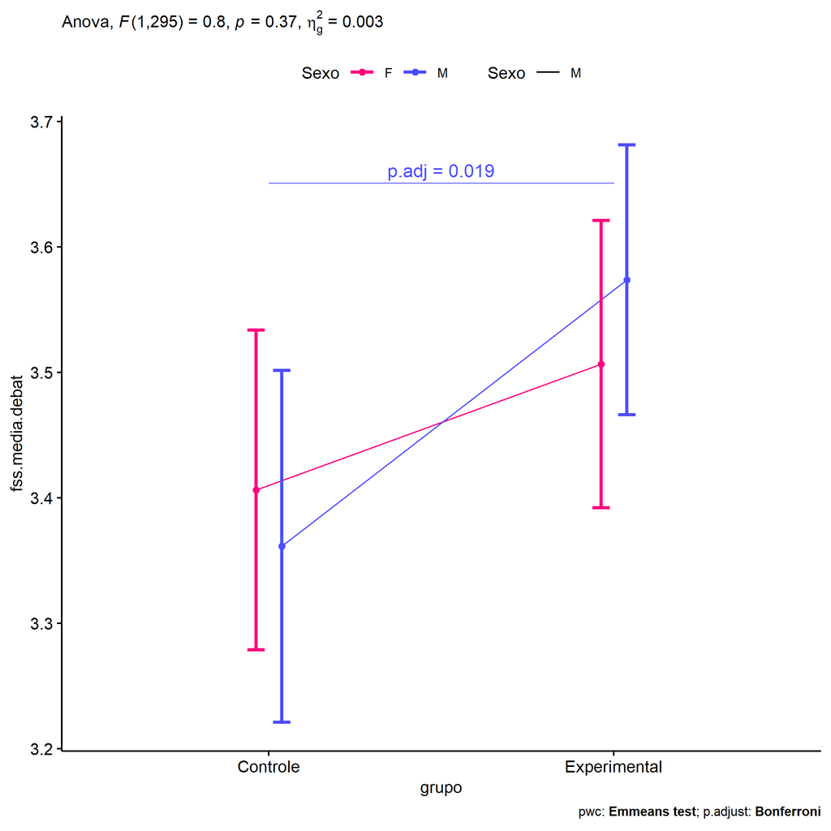

```r
if (!is.null(plots[["grupo"]]))
  plots[["grupo"]] + ggplot2::scale_color_manual(values = color[["Sexo"]])
```

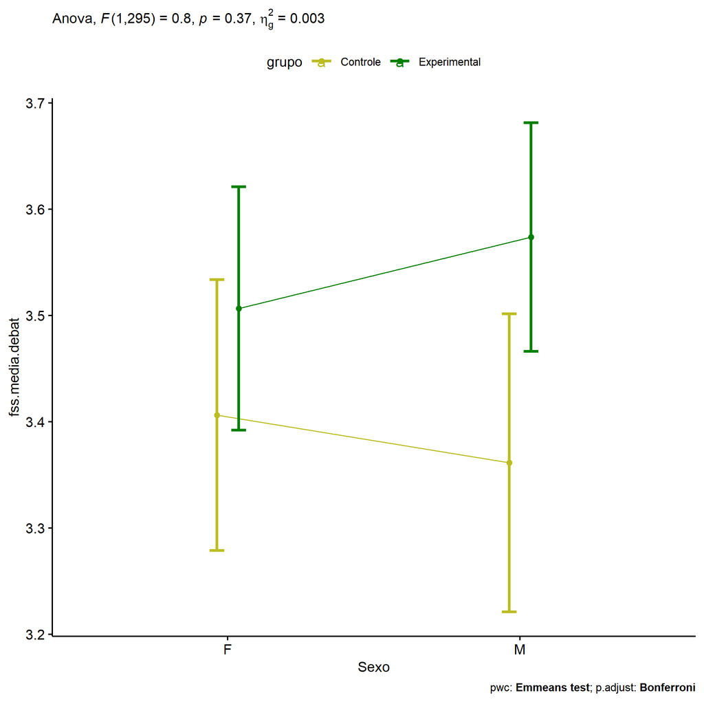

```r
if (!is.null(plots[["Sexo"]]))
  plots[["Sexo"]] + ggplot2::scale_color_manual(values = color[["grupo"]])
```

```r
plots <- twoWayAncovaBoxPlots(
  wdat, "fss.media.debat", c("grupo","Sexo"), aov, pwcs, covar = "dfs.media.debat",
  theme = "classic", color = color[["grupo:Sexo"]],
  subtitle = which(aov$Effect == "grupo:Sexo"))
```

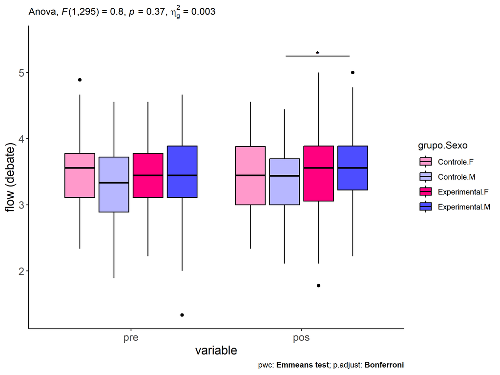

```r
plots[["grupo:Sexo"]] + ggplot2::ylab("flow (debate)") + ggplot2::scale_x_discrete(labels=c('pre', 'pos'))
```

```r
plots <- twoWayAncovaBoxPlots(
  wdat.long, "flow.debat", c("grupo","Sexo"), aov, pwc.long, pre.post = "time",
  theme = "classic", color = color$prepost)
```

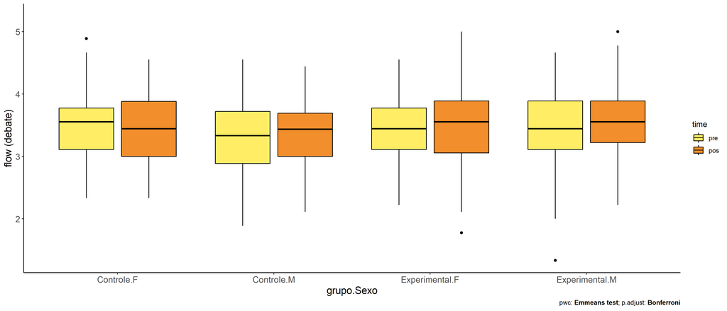

```r
plots[["grupo:Sexo"]] + ggplot2::ylab("flow (debate)")
```

### Checking linearity assumption

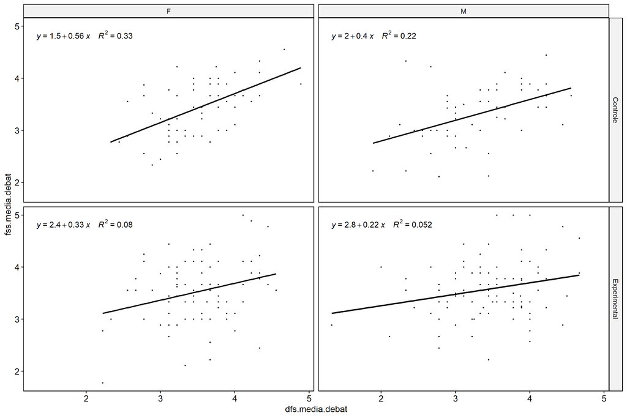

```r
ggscatter(wdat, x = "dfs.media.debat", y = "fss.media.debat", size = 0.5,
          facet.by = c("grupo","Sexo"), add = "reg.line")+
  stat_regline_equation(
    aes(label =  paste(..eq.label.., ..rr.label.., sep = "~~~~"))
  )
```

### Checking normality and homogeneity

```r
res <- augment(lm(fss.media.debat ~ dfs.media.debat + grupo*Sexo, data = wdat))
```

```r
shapiro_test(res$.resid)
```

```
## # A tibble: 1 × 3
##   variable   statistic p.value
##   <chr>          <dbl>   <dbl>
## 1 res$.resid     0.994   0.344
```

```r
levene_test(res, .resid ~ grupo*Sexo)
```

```
## # A tibble: 1 × 4
##     df1   df2 statistic     p
##   <int> <int>     <dbl> <dbl>
## 1     3   296      2.06 0.105
```

# ANCOVA and Pairwise for two factors **grupo:Zona**

## Without remove non-normal data

```r
pdat = remove_group_data(dat[!is.na(dat[["grupo"]]) & !is.na(dat[["Zona"]]),], "fss.media.debat", c("grupo","Zona"))

pdat.long <- rbind(pdat[,c("id","grupo","Zona")], pdat[,c("id","grupo","Zona")])
pdat.long[["time"]] <- c(rep("pre", nrow(pdat)), rep("pos", nrow(pdat)))
pdat.long[["time"]] <- factor(pdat.long[["time"]], c("pre","pos"))
pdat.long[["flow.debat"]] <- c(pdat[["dfs.media.debat"]], pdat[["fss.media.debat"]])

aov = anova_test(pdat, fss.media.debat ~ dfs.media.debat + grupo*Zona)
laov[["grupo:Zona"]] <- get_anova_table(aov)
```

```r
pwcs <- list()
pwcs[["Zona"]] <- emmeans_test(
  group_by(pdat, grupo), fss.media.debat ~ Zona,
  covariate = dfs.media.debat, p.adjust.method = "bonferroni")
pwcs[["grupo"]] <- emmeans_test(
  group_by(pdat, Zona), fss.media.debat ~ grupo,
  covariate = dfs.media.debat, p.adjust.method = "bonferroni")

pwc <- plyr::rbind.fill(pwcs[["grupo"]], pwcs[["Zona"]])
pwc <- pwc[,c("grupo","Zona", colnames(pwc)[!colnames(pwc) %in% c("grupo","Zona")])]
```

```r
pwc.long <- emmeans_test(dplyr::group_by_at(pdat.long, c("grupo","Zona")),
                         flow.debat ~ time,
                         p.adjust.method = "bonferroni")
lpwc[["grupo:Zona"]] <- plyr::rbind.fill(pwc, pwc.long)
```

```r
ds <- get.descriptives(pdat, "fss.media.debat", c("grupo","Zona"), covar = "dfs.media.debat")
ds <- merge(ds[ds$variable != "dfs.media.debat",],
            ds[ds$variable == "dfs.media.debat", !colnames(ds) %in% c("variable")],
            by = c("grupo","Zona"), all.x = T, suffixes = c("", ".dfs.media.debat"))
ds <- merge(get_emmeans(pwcs[["grupo"]]), ds, by = c("grupo","Zona"), suffixes = c(".emms", ""))
ds <- ds[,c("grupo","Zona","n","mean.dfs.media.debat","se.dfs.media.debat","mean","se","emmean","se.emms")]

colnames(ds) <- c("grupo","Zona", "N", paste0(c("M","SE")," (pre)"),
                  paste0(c("M","SE"), " (unadj)"), paste0(c("M", "SE"), " (adj)"))

lemms[["grupo:Zona"]] <- ds
```

## Computing ANCOVA and PairWise After removing non-normal data (OK)

```r
wdat = pdat

res = residuals(lm(fss.media.debat ~ dfs.media.debat + grupo*Zona, data = wdat))
non.normal = getNonNormal(res, wdat$id, plimit = 0.05)

wdat = wdat[!wdat$id %in% non.normal,]

wdat.long <- rbind(wdat[,c("id","grupo","Zona")], wdat[,c("id","grupo","Zona")])
wdat.long[["time"]] <- c(rep("pre", nrow(wdat)), rep("pos", nrow(wdat)))
wdat.long[["time"]] <- factor(wdat.long[["time"]], c("pre","pos"))
wdat.long[["flow.debat"]] <- c(wdat[["dfs.media.debat"]], wdat[["fss.media.debat"]])


ldat[["grupo:Zona"]] = wdat

(non.normal)
```

```r
aov = anova_test(wdat, fss.media.debat ~ dfs.media.debat + grupo*Zona)
laov[["grupo:Zona"]] <- merge(get_anova_table(aov), laov[["grupo:Zona"]], by="Effect", suffixes = c("","'"))

(df = get_anova_table(aov))
```

```
## ANOVA Table (type II tests)
##
##            Effect DFn DFd      F        p p<.05      ges
## 1 dfs.media.debat   1 253 49.686 1.71e-11     * 1.64e-01
## 2           grupo   1 253  3.940 4.80e-02     * 1.50e-02
## 3            Zona   1 253  0.461 4.98e-01       2.00e-03
## 4      grupo:Zona   1 253  0.014 9.06e-01       5.56e-05
```

| Effect | DFn | DFd | F | p | p<.05 | ges |
| --- | --- | --- | --- | --- | --- | --- |
| dfs.media.debat | 1 | 253 | 49.686 | 0.000 | * | 0.164 |
| grupo | 1 | 253 | 3.940 | 0.048 | * | 0.015 |
| Zona | 1 | 253 | 0.461 | 0.498 |  | 0.002 |
| grupo:Zona | 1 | 253 | 0.014 | 0.906 |  | 0.000 |

```r
pwcs <- list()
pwcs[["Zona"]] <- emmeans_test(
  group_by(wdat, grupo), fss.media.debat ~ Zona,
  covariate = dfs.media.debat, p.adjust.method = "bonferroni")
pwcs[["grupo"]] <- emmeans_test(
  group_by(wdat, Zona), fss.media.debat ~ grupo,
  covariate = dfs.media.debat, p.adjust.method = "bonferroni")

pwc <- plyr::rbind.fill(pwcs[["grupo"]], pwcs[["Zona"]])
pwc <- pwc[,c("grupo","Zona", colnames(pwc)[!colnames(pwc) %in% c("grupo","Zona")])]
```

| grupo | Zona | term | .y. | group1 | group2 | df | statistic | p | p.adj | p.adj.signif |
| --- | --- | --- | --- | --- | --- | --- | --- | --- | --- | --- |
|  | Rural | dfs.media.debat*grupo | fss.media.debat | Controle | Experimental | 253 | -1.316 | 0.189 | 0.189 | ns |
|  | Urbana | dfs.media.debat*grupo | fss.media.debat | Controle | Experimental | 253 | -1.490 | 0.138 | 0.138 | ns |
| Controle |  | dfs.media.debat*Zona | fss.media.debat | Rural | Urbana | 253 | -0.345 | 0.730 | 0.730 | ns |
| Experimental |  | dfs.media.debat*Zona | fss.media.debat | Rural | Urbana | 253 | -0.596 | 0.552 | 0.552 | ns |

```r
pwc.long <- emmeans_test(dplyr::group_by_at(wdat.long, c("grupo","Zona")),
                         flow.debat ~ time,
                         p.adjust.method = "bonferroni")
lpwc[["grupo:Zona"]] <- merge(plyr::rbind.fill(pwc, pwc.long), lpwc[["grupo:Zona"]], by=c("grupo","Zona","term",".y.","group1","group2"), suffixes = c("","'"))
```

| grupo | Zona | term | .y. | group1 | group2 | df | statistic | p | p.adj | p.adj.signif |
| --- | --- | --- | --- | --- | --- | --- | --- | --- | --- | --- |
| Controle | Rural | time | flow.debat | pre | pos | 508 | 0.827 | 0.408 | 0.408 | ns |
| Controle | Urbana | time | flow.debat | pre | pos | 508 | -0.273 | 0.785 | 0.785 | ns |
| Experimental | Rural | time | flow.debat | pre | pos | 508 | -0.460 | 0.646 | 0.646 | ns |
| Experimental | Urbana | time | flow.debat | pre | pos | 508 | -0.935 | 0.350 | 0.350 | ns |

```r
ds <- get.descriptives(wdat, "fss.media.debat", c("grupo","Zona"), covar = "dfs.media.debat")
ds <- merge(ds[ds$variable != "dfs.media.debat",],
            ds[ds$variable == "dfs.media.debat", !colnames(ds) %in% c("variable")],
            by = c("grupo","Zona"), all.x = T, suffixes = c("", ".dfs.media.debat"))
ds <- merge(get_emmeans(pwcs[["grupo"]]), ds, by = c("grupo","Zona"), suffixes = c(".emms", ""))
ds <- ds[,c("grupo","Zona","n","mean.dfs.media.debat","se.dfs.media.debat","mean","se","emmean","se.emms")]

colnames(ds) <- c("grupo","Zona", "N", paste0(c("M","SE")," (pre)"),
                  paste0(c("M","SE"), " (unadj)"), paste0(c("M", "SE"), " (adj)"))

lemms[["grupo:Zona"]] <- merge(ds, lemms[["grupo:Zona"]], by=c("grupo","Zona"), suffixes = c("","'"))
```

| grupo | Zona | N | M (pre) | SE (pre) | M (unadj) | SE (unadj) | M (adj) | SE (adj) |
| --- | --- | --- | --- | --- | --- | --- | --- | --- |
| Controle | Rural | 53 | 3.491 | 0.066 | 3.401 | 0.064 | 3.386 | 0.071 |
| Controle | Urbana | 54 | 3.346 | 0.086 | 3.376 | 0.080 | 3.420 | 0.071 |
| Experimental | Rural | 75 | 3.474 | 0.071 | 3.517 | 0.065 | 3.508 | 0.060 |
| Experimental | Urbana | 76 | 3.487 | 0.056 | 3.572 | 0.071 | 3.559 | 0.060 |

### Plots for ancova

```r
plots <- twoWayAncovaPlots(
  wdat, "fss.media.debat", c("grupo","Zona"), aov, pwcs, addParam = c("mean_se"),
  font.label.size=10, step.increase=0.05, p.label="p.adj",
  subtitle = which(aov$Effect == "grupo:Zona"))
```

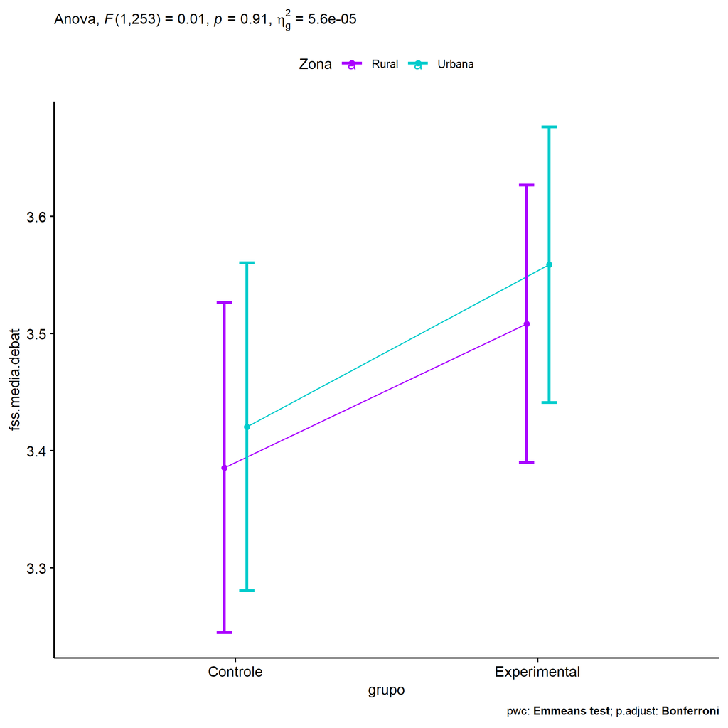

```r
if (!is.null(plots[["grupo"]]))
  plots[["grupo"]] + ggplot2::scale_color_manual(values = color[["Zona"]])
```

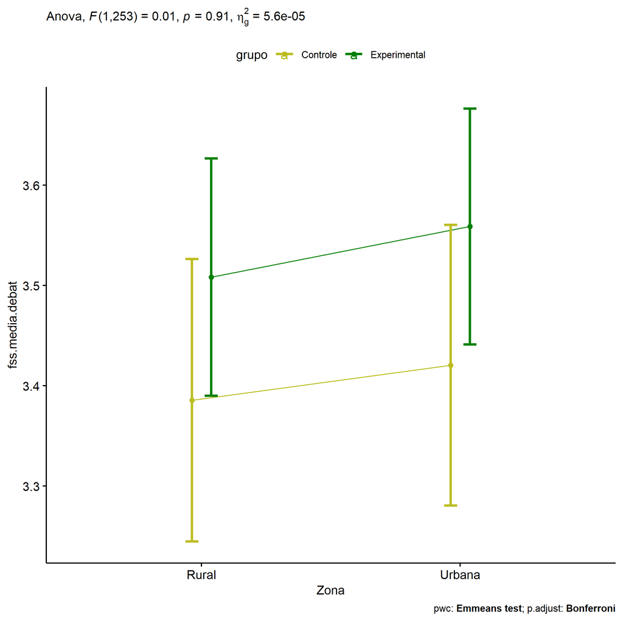

```r
if (!is.null(plots[["Zona"]]))
  plots[["Zona"]] + ggplot2::scale_color_manual(values = color[["grupo"]])
```

```r
plots <- twoWayAncovaBoxPlots(
  wdat, "fss.media.debat", c("grupo","Zona"), aov, pwcs, covar = "dfs.media.debat",
  theme = "classic", color = color[["grupo:Zona"]],
  subtitle = which(aov$Effect == "grupo:Zona"))
```

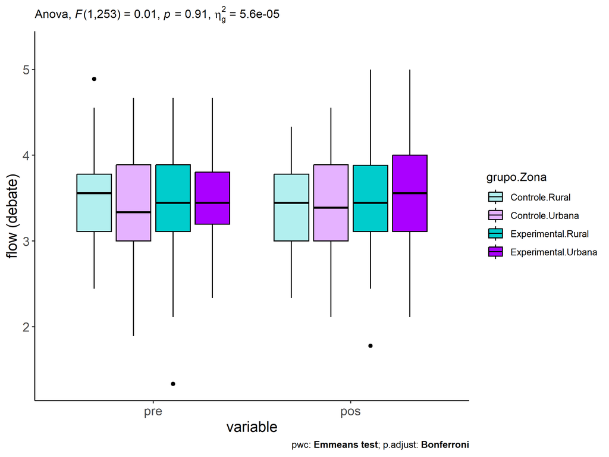

```r
plots[["grupo:Zona"]] + ggplot2::ylab("flow (debate)") + ggplot2::scale_x_discrete(labels=c('pre', 'pos'))
```

```r
plots <- twoWayAncovaBoxPlots(
  wdat.long, "flow.debat", c("grupo","Zona"), aov, pwc.long, pre.post = "time",
  theme = "classic", color = color$prepost)
```

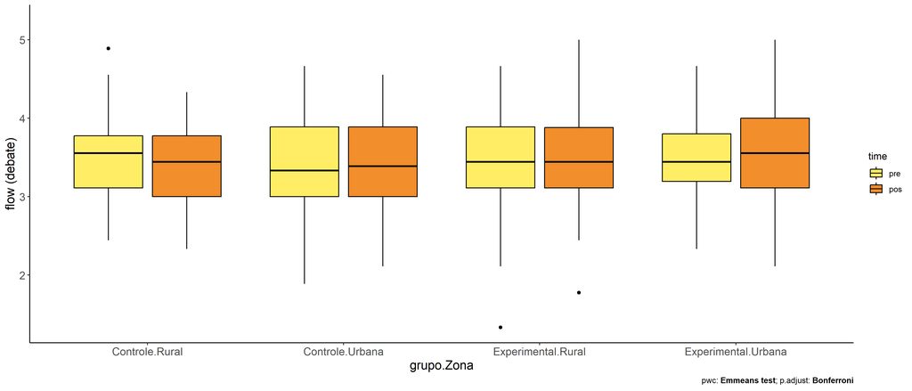

```r
plots[["grupo:Zona"]] + ggplot2::ylab("flow (debate)")
```

### Checking linearity assumption

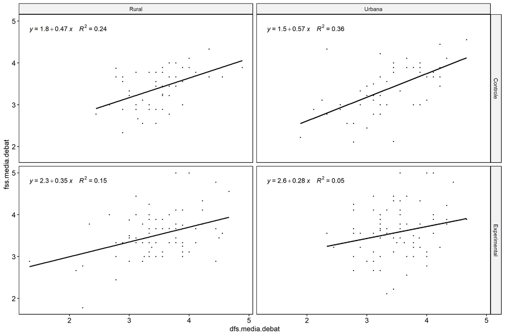

```r
ggscatter(wdat, x = "dfs.media.debat", y = "fss.media.debat", size = 0.5,
          facet.by = c("grupo","Zona"), add = "reg.line")+
  stat_regline_equation(
    aes(label =  paste(..eq.label.., ..rr.label.., sep = "~~~~"))
  )
```

### Checking normality and homogeneity

```r
res <- augment(lm(fss.media.debat ~ dfs.media.debat + grupo*Zona, data = wdat))
```

```r
shapiro_test(res$.resid)
```

```
## # A tibble: 1 × 3
##   variable   statistic p.value
##   <chr>          <dbl>   <dbl>
## 1 res$.resid     0.996   0.723
```

```r
levene_test(res, .resid ~ grupo*Zona)
```

```
## # A tibble: 1 × 4
##     df1   df2 statistic      p
##   <int> <int>     <dbl>  <dbl>
## 1     3   254      3.13 0.0263
```

# ANCOVA and Pairwise for two factors **grupo:Cor.Raca**

## Without remove non-normal data

```r
pdat = remove_group_data(dat[!is.na(dat[["grupo"]]) & !is.na(dat[["Cor.Raca"]]),], "fss.media.debat", c("grupo","Cor.Raca"))

pdat.long <- rbind(pdat[,c("id","grupo","Cor.Raca")], pdat[,c("id","grupo","Cor.Raca")])
pdat.long[["time"]] <- c(rep("pre", nrow(pdat)), rep("pos", nrow(pdat)))
pdat.long[["time"]] <- factor(pdat.long[["time"]], c("pre","pos"))
pdat.long[["flow.debat"]] <- c(pdat[["dfs.media.debat"]], pdat[["fss.media.debat"]])

aov = anova_test(pdat, fss.media.debat ~ dfs.media.debat + grupo*Cor.Raca)
laov[["grupo:Cor.Raca"]] <- get_anova_table(aov)
```

```r
pwcs <- list()
pwcs[["Cor.Raca"]] <- emmeans_test(
  group_by(pdat, grupo), fss.media.debat ~ Cor.Raca,
  covariate = dfs.media.debat, p.adjust.method = "bonferroni")
pwcs[["grupo"]] <- emmeans_test(
  group_by(pdat, Cor.Raca), fss.media.debat ~ grupo,
  covariate = dfs.media.debat, p.adjust.method = "bonferroni")

pwc <- plyr::rbind.fill(pwcs[["grupo"]], pwcs[["Cor.Raca"]])
pwc <- pwc[,c("grupo","Cor.Raca", colnames(pwc)[!colnames(pwc) %in% c("grupo","Cor.Raca")])]
```

```r
pwc.long <- emmeans_test(dplyr::group_by_at(pdat.long, c("grupo","Cor.Raca")),
                         flow.debat ~ time,
                         p.adjust.method = "bonferroni")
lpwc[["grupo:Cor.Raca"]] <- plyr::rbind.fill(pwc, pwc.long)
```

```r
ds <- get.descriptives(pdat, "fss.media.debat", c("grupo","Cor.Raca"), covar = "dfs.media.debat")
ds <- merge(ds[ds$variable != "dfs.media.debat",],
            ds[ds$variable == "dfs.media.debat", !colnames(ds) %in% c("variable")],
            by = c("grupo","Cor.Raca"), all.x = T, suffixes = c("", ".dfs.media.debat"))
ds <- merge(get_emmeans(pwcs[["grupo"]]), ds, by = c("grupo","Cor.Raca"), suffixes = c(".emms", ""))
ds <- ds[,c("grupo","Cor.Raca","n","mean.dfs.media.debat","se.dfs.media.debat","mean","se","emmean","se.emms")]

colnames(ds) <- c("grupo","Cor.Raca", "N", paste0(c("M","SE")," (pre)"),
                  paste0(c("M","SE"), " (unadj)"), paste0(c("M", "SE"), " (adj)"))

lemms[["grupo:Cor.Raca"]] <- ds
```

## Computing ANCOVA and PairWise After removing non-normal data (OK)

```r
wdat = pdat

res = residuals(lm(fss.media.debat ~ dfs.media.debat + grupo*Cor.Raca, data = wdat))
non.normal = getNonNormal(res, wdat$id, plimit = 0.05)

wdat = wdat[!wdat$id %in% non.normal,]

wdat.long <- rbind(wdat[,c("id","grupo","Cor.Raca")], wdat[,c("id","grupo","Cor.Raca")])
wdat.long[["time"]] <- c(rep("pre", nrow(wdat)), rep("pos", nrow(wdat)))
wdat.long[["time"]] <- factor(wdat.long[["time"]], c("pre","pos"))
wdat.long[["flow.debat"]] <- c(wdat[["dfs.media.debat"]], wdat[["fss.media.debat"]])


ldat[["grupo:Cor.Raca"]] = wdat

(non.normal)
```

```r
aov = anova_test(wdat, fss.media.debat ~ dfs.media.debat + grupo*Cor.Raca)
laov[["grupo:Cor.Raca"]] <- merge(get_anova_table(aov), laov[["grupo:Cor.Raca"]], by="Effect", suffixes = c("","'"))

(df = get_anova_table(aov))
```

```
## ANOVA Table (type II tests)
##
##            Effect DFn DFd      F        p p<.05   ges
## 1 dfs.media.debat   1 107 24.219 3.13e-06     * 0.185
## 2           grupo   1 107  1.519 2.21e-01       0.014
## 3        Cor.Raca   1 107  0.668 4.15e-01       0.006
## 4  grupo:Cor.Raca   1 107  1.150 2.86e-01       0.011
```

| Effect | DFn | DFd | F | p | p<.05 | ges |
| --- | --- | --- | --- | --- | --- | --- |
| dfs.media.debat | 1 | 107 | 24.219 | 0.000 | * | 0.185 |
| grupo | 1 | 107 | 1.519 | 0.221 |  | 0.014 |
| Cor.Raca | 1 | 107 | 0.668 | 0.415 |  | 0.006 |
| grupo:Cor.Raca | 1 | 107 | 1.150 | 0.286 |  | 0.011 |

```r
pwcs <- list()
pwcs[["Cor.Raca"]] <- emmeans_test(
  group_by(wdat, grupo), fss.media.debat ~ Cor.Raca,
  covariate = dfs.media.debat, p.adjust.method = "bonferroni")
pwcs[["grupo"]] <- emmeans_test(
  group_by(wdat, Cor.Raca), fss.media.debat ~ grupo,
  covariate = dfs.media.debat, p.adjust.method = "bonferroni")

pwc <- plyr::rbind.fill(pwcs[["grupo"]], pwcs[["Cor.Raca"]])
pwc <- pwc[,c("grupo","Cor.Raca", colnames(pwc)[!colnames(pwc) %in% c("grupo","Cor.Raca")])]
```

| grupo | Cor.Raca | term | .y. | group1 | group2 | df | statistic | p | p.adj | p.adj.signif |
| --- | --- | --- | --- | --- | --- | --- | --- | --- | --- | --- |
|  | Branca | dfs.media.debat*grupo | fss.media.debat | Controle | Experimental | 107 | 0.329 | 0.743 | 0.743 | ns |
|  | Parda | dfs.media.debat*grupo | fss.media.debat | Controle | Experimental | 107 | -1.600 | 0.113 | 0.113 | ns |
| Controle |  | dfs.media.debat*Cor.Raca | fss.media.debat | Branca | Parda | 107 | 0.076 | 0.940 | 0.940 | ns |
| Experimental |  | dfs.media.debat*Cor.Raca | fss.media.debat | Branca | Parda | 107 | -1.346 | 0.181 | 0.181 | ns |

```r
pwc.long <- emmeans_test(dplyr::group_by_at(wdat.long, c("grupo","Cor.Raca")),
                         flow.debat ~ time,
                         p.adjust.method = "bonferroni")
lpwc[["grupo:Cor.Raca"]] <- merge(plyr::rbind.fill(pwc, pwc.long), lpwc[["grupo:Cor.Raca"]], by=c("grupo","Cor.Raca","term",".y.","group1","group2"), suffixes = c("","'"))
```

| grupo | Cor.Raca | term | .y. | group1 | group2 | df | statistic | p | p.adj | p.adj.signif |
| --- | --- | --- | --- | --- | --- | --- | --- | --- | --- | --- |
| Controle | Branca | time | flow.debat | pre | pos | 216 | -0.161 | 0.872 | 0.872 | ns |
| Controle | Parda | time | flow.debat | pre | pos | 216 | 0.175 | 0.862 | 0.862 | ns |
| Experimental | Branca | time | flow.debat | pre | pos | 216 | 0.445 | 0.657 | 0.657 | ns |
| Experimental | Parda | time | flow.debat | pre | pos | 216 | -1.128 | 0.260 | 0.260 | ns |

```r
ds <- get.descriptives(wdat, "fss.media.debat", c("grupo","Cor.Raca"), covar = "dfs.media.debat")
ds <- merge(ds[ds$variable != "dfs.media.debat",],
            ds[ds$variable == "dfs.media.debat", !colnames(ds) %in% c("variable")],
            by = c("grupo","Cor.Raca"), all.x = T, suffixes = c("", ".dfs.media.debat"))
ds <- merge(get_emmeans(pwcs[["grupo"]]), ds, by = c("grupo","Cor.Raca"), suffixes = c(".emms", ""))
ds <- ds[,c("grupo","Cor.Raca","n","mean.dfs.media.debat","se.dfs.media.debat","mean","se","emmean","se.emms")]

colnames(ds) <- c("grupo","Cor.Raca", "N", paste0(c("M","SE")," (pre)"),
                  paste0(c("M","SE"), " (unadj)"), paste0(c("M", "SE"), " (adj)"))

lemms[["grupo:Cor.Raca"]] <- merge(ds, lemms[["grupo:Cor.Raca"]], by=c("grupo","Cor.Raca"), suffixes = c("","'"))
```

| grupo | Cor.Raca | N | M (pre) | SE (pre) | M (unadj) | SE (unadj) | M (adj) | SE (adj) |
| --- | --- | --- | --- | --- | --- | --- | --- | --- |
| Controle | Branca | 17 | 3.333 | 0.174 | 3.366 | 0.130 | 3.396 | 0.125 |
| Controle | Parda | 41 | 3.407 | 0.088 | 3.384 | 0.085 | 3.385 | 0.080 |
| Experimental | Branca | 11 | 3.465 | 0.171 | 3.352 | 0.194 | 3.331 | 0.155 |
| Experimental | Parda | 43 | 3.428 | 0.096 | 3.572 | 0.088 | 3.564 | 0.078 |

### Plots for ancova

```r
plots <- twoWayAncovaPlots(
  wdat, "fss.media.debat", c("grupo","Cor.Raca"), aov, pwcs, addParam = c("mean_se"),
  font.label.size=10, step.increase=0.05, p.label="p.adj",
  subtitle = which(aov$Effect == "grupo:Cor.Raca"))
```

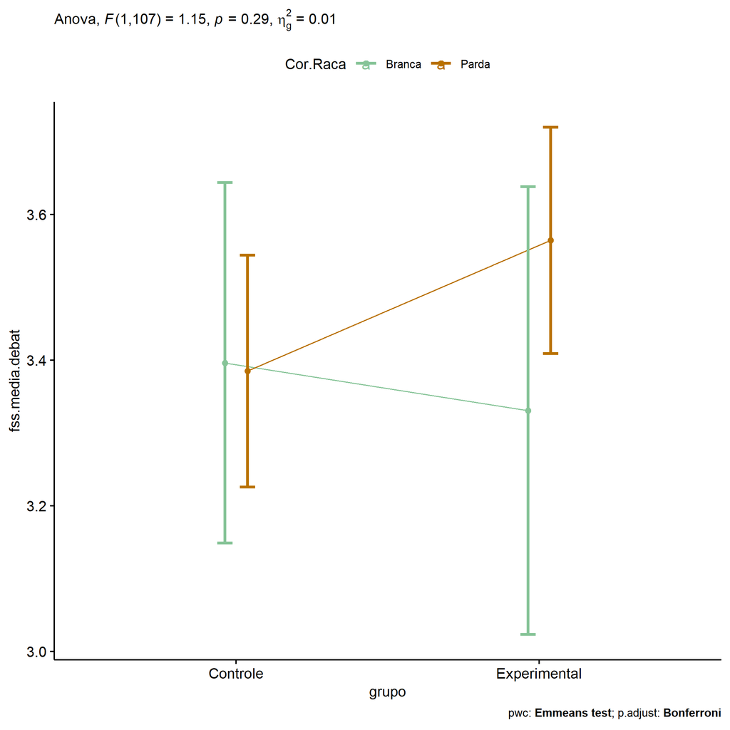

```r
if (!is.null(plots[["grupo"]]))
  plots[["grupo"]] + ggplot2::scale_color_manual(values = color[["Cor.Raca"]])
```

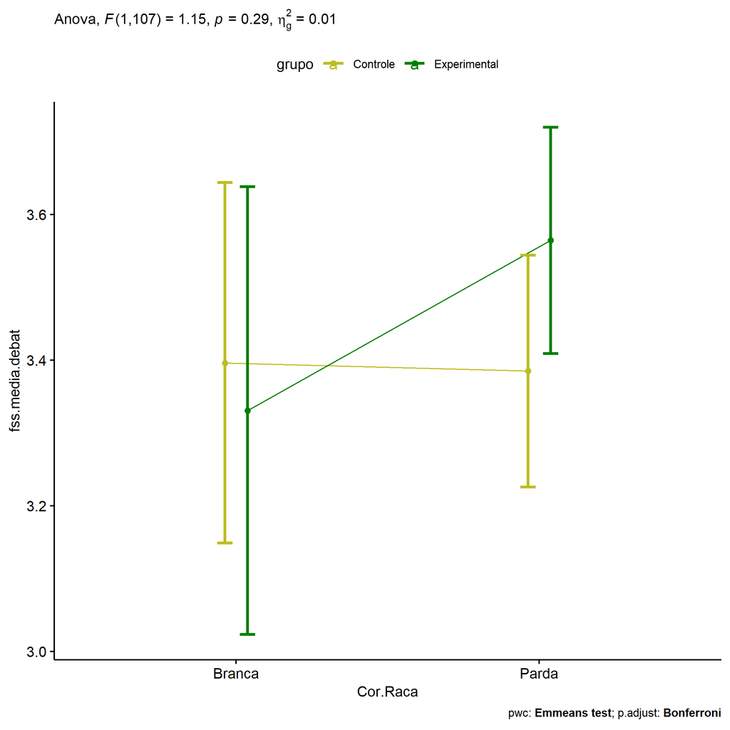

```r
if (!is.null(plots[["Cor.Raca"]]))
  plots[["Cor.Raca"]] + ggplot2::scale_color_manual(values = color[["grupo"]])
```

```r
plots <- twoWayAncovaBoxPlots(
  wdat, "fss.media.debat", c("grupo","Cor.Raca"), aov, pwcs, covar = "dfs.media.debat",
  theme = "classic", color = color[["grupo:Cor.Raca"]],
  subtitle = which(aov$Effect == "grupo:Cor.Raca"))
```

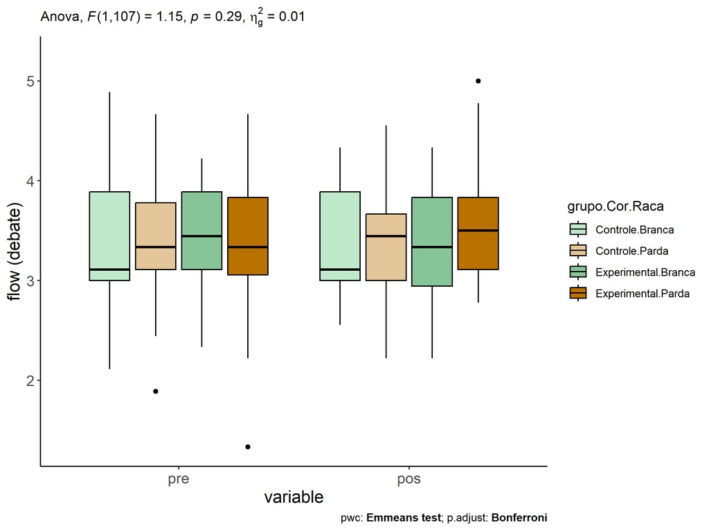

```r
plots[["grupo:Cor.Raca"]] + ggplot2::ylab("flow (debate)") + ggplot2::scale_x_discrete(labels=c('pre', 'pos'))
```

```r
plots <- twoWayAncovaBoxPlots(
  wdat.long, "flow.debat", c("grupo","Cor.Raca"), aov, pwc.long, pre.post = "time",
  theme = "classic", color = color$prepost)
```

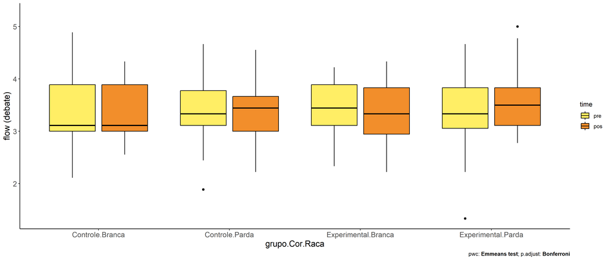

```r
plots[["grupo:Cor.Raca"]] + ggplot2::ylab("flow (debate)")
```

### Checking linearity assumption

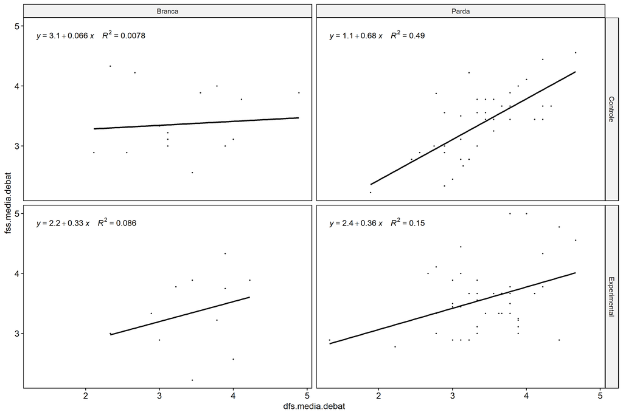

```r
ggscatter(wdat, x = "dfs.media.debat", y = "fss.media.debat", size = 0.5,
          facet.by = c("grupo","Cor.Raca"), add = "reg.line")+
  stat_regline_equation(
    aes(label =  paste(..eq.label.., ..rr.label.., sep = "~~~~"))
  )
```

### Checking normality and homogeneity

```r
res <- augment(lm(fss.media.debat ~ dfs.media.debat + grupo*Cor.Raca, data = wdat))
```

```r
shapiro_test(res$.resid)
```

```
## # A tibble: 1 × 3
##   variable   statistic p.value
##   <chr>          <dbl>   <dbl>
## 1 res$.resid     0.985   0.268
```

```r
levene_test(res, .resid ~ grupo*Cor.Raca)
```

```
## # A tibble: 1 × 4
##     df1   df2 statistic     p
##   <int> <int>     <dbl> <dbl>
## 1     3   108     0.539 0.657
```

# Summary of Results

## Descriptive Statistics

```r
df <- get.descriptives(ldat[["grupo"]], c(dv.pre, dv.pos), c("grupo"),
                       include.global = T, symmetry.test = T, normality.test = F)
df <- plyr::rbind.fill(
  df, do.call(plyr::rbind.fill, lapply(lfatores2, FUN = function(f) {
    if (nrow(dat) > 0 && sum(!is.na(unique(dat[[f]]))) > 1)
      get.descriptives(ldat[[paste0("grupo:",f)]], c(dv.pre,dv.pos), c("grupo", f),
                       symmetry.test = T, normality.test = F)
    }))
)
(df <- df[,c(fatores1[fatores1 %in% colnames(df)],"variable",
             colnames(df)[!colnames(df) %in% c(fatores1,"variable")])])
```

```
##           grupo Sexo   Zona Cor.Raca        variable   n  mean median   min   max    sd    se    ci   iqr
## 1      Controle <NA>   <NA>     <NA> dfs.media.debat 123 3.404  3.444 1.889 4.889 0.584 0.053 0.104 0.778
## 2  Experimental <NA>   <NA>     <NA> dfs.media.debat 177 3.463  3.444 1.333 4.667 0.566 0.043 0.084 0.778
## 3          <NA> <NA>   <NA>     <NA> dfs.media.debat 300 3.439  3.444 1.333 4.889 0.573 0.033 0.065 0.778
## 4      Controle <NA>   <NA>     <NA> fss.media.debat 123 3.374  3.444 2.111 4.556 0.526 0.047 0.094 0.778
## 5  Experimental <NA>   <NA>     <NA> fss.media.debat 177 3.551  3.556 1.778 5.000 0.591 0.044 0.088 0.778
## 6          <NA> <NA>   <NA>     <NA> fss.media.debat 300 3.478  3.444 1.778 5.000 0.571 0.033 0.065 0.889
## 7      Controle    F   <NA>     <NA> dfs.media.debat  67 3.495  3.556 2.333 4.889 0.520 0.064 0.127 0.667
## 8      Controle    M   <NA>     <NA> dfs.media.debat  56 3.294  3.333 1.889 4.556 0.639 0.085 0.171 0.833
## 9  Experimental    F   <NA>     <NA> dfs.media.debat  83 3.475  3.444 2.222 4.556 0.526 0.058 0.115 0.667
## 10 Experimental    M   <NA>     <NA> dfs.media.debat  94 3.452  3.444 1.333 4.667 0.602 0.062 0.123 0.778
## 11     Controle    F   <NA>     <NA> fss.media.debat  67 3.426  3.444 2.333 4.556 0.508 0.062 0.124 0.882
## 12     Controle    M   <NA>     <NA> fss.media.debat  56 3.311  3.437 2.111 4.444 0.544 0.073 0.146 0.694
## 13 Experimental    F   <NA>     <NA> fss.media.debat  83 3.519  3.556 1.778 5.000 0.605 0.066 0.132 0.833
## 14 Experimental    M   <NA>     <NA> fss.media.debat  94 3.578  3.556 2.222 5.000 0.579 0.060 0.119 0.667
```

[output cut: 47 more lines]

| grupo | Sexo | Zona | Cor.Raca | variable | n | mean | median | min | max | sd | se | ci | iqr | symmetry | skewness | kurtosis |
| --- | --- | --- | --- | --- | --- | --- | --- | --- | --- | --- | --- | --- | --- | --- | --- | --- |
| Controle |  |  |  | dfs.media.debat | 123 | 3.404 | 3.444 | 1.889 | 4.889 | 0.584 | 0.053 | 0.104 | 0.778 | YES | -0.067 | -0.370 |
| Experimental |  |  |  | dfs.media.debat | 177 | 3.463 | 3.444 | 1.333 | 4.667 | 0.566 | 0.043 | 0.084 | 0.778 | YES | -0.379 | 0.470 |
|  |  |  |  | dfs.media.debat | 300 | 3.439 | 3.444 | 1.333 | 4.889 | 0.573 | 0.033 | 0.065 | 0.778 | YES | -0.249 | 0.095 |
| Controle |  |  |  | fss.media.debat | 123 | 3.374 | 3.444 | 2.111 | 4.556 | 0.526 | 0.047 | 0.094 | 0.778 | YES | -0.189 | -0.507 |
| Experimental |  |  |  | fss.media.debat | 177 | 3.551 | 3.556 | 1.778 | 5.000 | 0.591 | 0.044 | 0.088 | 0.778 | YES | 0.114 | 0.253 |
|  |  |  |  | fss.media.debat | 300 | 3.478 | 3.444 | 1.778 | 5.000 | 0.571 | 0.033 | 0.065 | 0.889 | YES | 0.063 | 0.151 |
| Controle | F |  |  | dfs.media.debat | 67 | 3.495 | 3.556 | 2.333 | 4.889 | 0.520 | 0.064 | 0.127 | 0.667 | YES | 0.114 | -0.128 |
| Controle | M |  |  | dfs.media.debat | 56 | 3.294 | 3.333 | 1.889 | 4.556 | 0.639 | 0.085 | 0.171 | 0.833 | YES | -0.016 | -0.814 |
| Experimental | F |  |  | dfs.media.debat | 83 | 3.475 | 3.444 | 2.222 | 4.556 | 0.526 | 0.058 | 0.115 | 0.667 | YES | -0.098 | -0.349 |
| Experimental | M |  |  | dfs.media.debat | 94 | 3.452 | 3.444 | 1.333 | 4.667 | 0.602 | 0.062 | 0.123 | 0.778 | NO | -0.524 | 0.715 |
| Controle | F |  |  | fss.media.debat | 67 | 3.426 | 3.444 | 2.333 | 4.556 | 0.508 | 0.062 | 0.124 | 0.882 | YES | -0.077 | -0.882 |
| Controle | M |  |  | fss.media.debat | 56 | 3.311 | 3.437 | 2.111 | 4.444 | 0.544 | 0.073 | 0.146 | 0.694 | YES | -0.257 | -0.378 |
| Experimental | F |  |  | fss.media.debat | 83 | 3.519 | 3.556 | 1.778 | 5.000 | 0.605 | 0.066 | 0.132 | 0.833 | YES | -0.156 | 0.200 |
| Experimental | M |  |  | fss.media.debat | 94 | 3.578 | 3.556 | 2.222 | 5.000 | 0.579 | 0.060 | 0.119 | 0.667 | YES | 0.397 | 0.113 |
| Controle |  | Rural |  | dfs.media.debat | 53 | 3.491 | 3.556 | 2.444 | 4.889 | 0.483 | 0.066 | 0.133 | 0.667 | YES | 0.352 | 0.280 |
| Controle |  | Urbana |  | dfs.media.debat | 54 | 3.346 | 3.333 | 1.889 | 4.667 | 0.630 | 0.086 | 0.172 | 0.889 | YES | -0.181 | -0.649 |
| Experimental |  | Rural |  | dfs.media.debat | 75 | 3.474 | 3.444 | 1.333 | 4.667 | 0.616 | 0.071 | 0.142 | 0.778 | NO | -0.565 | 0.919 |
| Experimental |  | Urbana |  | dfs.media.debat | 76 | 3.487 | 3.444 | 2.333 | 4.667 | 0.487 | 0.056 | 0.111 | 0.608 | YES | 0.055 | -0.440 |
| Controle |  | Rural |  | fss.media.debat | 53 | 3.401 | 3.444 | 2.333 | 4.333 | 0.462 | 0.064 | 0.127 | 0.778 | YES | -0.294 | -0.853 |
| Controle |  | Urbana |  | fss.media.debat | 54 | 3.376 | 3.389 | 2.111 | 4.556 | 0.590 | 0.080 | 0.161 | 0.889 | YES | -0.174 | -0.683 |
| Experimental |  | Rural |  | fss.media.debat | 75 | 3.517 | 3.444 | 1.778 | 5.000 | 0.563 | 0.065 | 0.130 | 0.771 | YES | 0.196 | 0.782 |
| Experimental |  | Urbana |  | fss.media.debat | 76 | 3.572 | 3.556 | 2.111 | 5.000 | 0.620 | 0.071 | 0.142 | 0.889 | YES | 0.168 | -0.187 |
| Controle |  |  | Branca | dfs.media.debat | 17 | 3.333 | 3.111 | 2.111 | 4.889 | 0.716 | 0.174 | 0.368 | 0.889 | YES | 0.209 | -0.654 |
| Controle |  |  | Parda | dfs.media.debat | 41 | 3.407 | 3.333 | 1.889 | 4.667 | 0.564 | 0.088 | 0.178 | 0.667 | YES | -0.125 | 0.006 |
| Experimental |  |  | Branca | dfs.media.debat | 11 | 3.465 | 3.444 | 2.333 | 4.222 | 0.566 | 0.171 | 0.380 | 0.778 | YES | -0.492 | -0.979 |
| Experimental |  |  | Parda | dfs.media.debat | 43 | 3.428 | 3.333 | 1.333 | 4.667 | 0.630 | 0.096 | 0.194 | 0.778 | NO | -0.632 | 1.206 |
| Controle |  |  | Branca | fss.media.debat | 17 | 3.366 | 3.111 | 2.556 | 4.333 | 0.535 | 0.130 | 0.275 | 0.889 | YES | 0.445 | -1.305 |
| Controle |  |  | Parda | fss.media.debat | 41 | 3.384 | 3.444 | 2.222 | 4.556 | 0.545 | 0.085 | 0.172 | 0.667 | YES | -0.086 | -0.500 |
| Experimental |  |  | Branca | fss.media.debat | 11 | 3.352 | 3.333 | 2.222 | 4.333 | 0.642 | 0.194 | 0.431 | 0.889 | YES | -0.232 | -1.279 |
| Experimental |  |  | Parda | fss.media.debat | 43 | 3.572 | 3.500 | 2.778 | 5.000 | 0.579 | 0.088 | 0.178 | 0.722 | NO | 0.820 | -0.001 |

## ANCOVA Table Comparison

```r
df <- do.call(plyr::rbind.fill, laov)
(df <- df[!duplicated(df$Effect),])
```

```
##             Effect DFn DFd      F        p p<.05      ges DFn' DFd'     F'       p' p<.05'     ges'
## 1  dfs.media.debat   1 297 43.018 2.40e-10     * 1.27e-01    1  297 43.018 2.40e-10      * 1.27e-01
## 2            grupo   1 297  6.324 1.20e-02     * 2.10e-02    1  297  6.324 1.20e-02      * 2.10e-02
## 5       grupo:Sexo   1 295  0.802 3.71e-01       3.00e-03    1  295  0.802 3.71e-01        3.00e-03
## 6             Sexo   1 295  0.125 7.24e-01       4.22e-04    1  295  0.125 7.24e-01        4.22e-04
## 9       grupo:Zona   1 253  0.014 9.06e-01       5.56e-05    1  253  0.014 9.06e-01        5.56e-05
## 10            Zona   1 253  0.461 4.98e-01       2.00e-03    1  253  0.461 4.98e-01        2.00e-03
## 11        Cor.Raca   1 107  0.668 4.15e-01       6.00e-03    1  107  0.668 4.15e-01        6.00e-03
## 14  grupo:Cor.Raca   1 107  1.150 2.86e-01       1.10e-02    1  107  1.150 2.86e-01        1.10e-02
```

|  | Effect | DFn | DFd | F | p | p<.05 | ges | DFn’ | DFd’ | F’ | p’ | p<.05’ | ges’ |
| --- | --- | --- | --- | --- | --- | --- | --- | --- | --- | --- | --- | --- | --- |
| 1 | dfs.media.debat | 1 | 297 | 43.018 | 0.000 | * | 0.127 | 1 | 297 | 43.018 | 0.000 | * | 0.127 |
| 2 | grupo | 1 | 297 | 6.324 | 0.012 | * | 0.021 | 1 | 297 | 6.324 | 0.012 | * | 0.021 |
| 5 | grupo:Sexo | 1 | 295 | 0.802 | 0.371 |  | 0.003 | 1 | 295 | 0.802 | 0.371 |  | 0.003 |
| 6 | Sexo | 1 | 295 | 0.125 | 0.724 |  | 0.000 | 1 | 295 | 0.125 | 0.724 |  | 0.000 |
| 9 | grupo:Zona | 1 | 253 | 0.014 | 0.906 |  | 0.000 | 1 | 253 | 0.014 | 0.906 |  | 0.000 |
| 10 | Zona | 1 | 253 | 0.461 | 0.498 |  | 0.002 | 1 | 253 | 0.461 | 0.498 |  | 0.002 |
| 11 | Cor.Raca | 1 | 107 | 0.668 | 0.415 |  | 0.006 | 1 | 107 | 0.668 | 0.415 |  | 0.006 |
| 14 | grupo:Cor.Raca | 1 | 107 | 1.150 | 0.286 |  | 0.011 | 1 | 107 | 1.150 | 0.286 |  | 0.011 |

## PairWise Table Comparison

```r
df <- do.call(plyr::rbind.fill, lpwc)
df <- df[,c(names(lfatores), names(df)[!names(df) %in% c(names(lfatores),"term",".y.")])]
```

| grupo | Sexo | Zona | Cor.Raca | group1 | group2 | df | statistic | p | p.adj | p.adj.signif | df’ | statistic’ | p’ | p.adj’ | p.adj.signif’ |
| --- | --- | --- | --- | --- | --- | --- | --- | --- | --- | --- | --- | --- | --- | --- | --- |
| Controle |  |  |  | pre | pos | 596 | 0.416 | 0.678 | 0.678 | ns | 596 | 0.416 | 0.678 | 0.678 | ns |
| Experimental |  |  |  | pre | pos | 596 | -1.453 | 0.147 | 0.147 | ns | 596 | -1.453 | 0.147 | 0.147 | ns |
|  |  |  |  | Controle | Experimental | 297 | -2.515 | 0.012 | 0.012 | * | 297 | -2.515 | 0.012 | 0.012 | * |
| Controle | F |  |  | pre | pos | 592 | 0.707 | 0.480 | 0.480 | ns | 592 | 0.707 | 0.480 | 0.480 | ns |
| Controle | M |  |  | pre | pos | 592 | -0.156 | 0.876 | 0.876 | ns | 592 | -0.156 | 0.876 | 0.876 | ns |
| Controle |  |  |  | F | M | 295 | 0.465 | 0.642 | 0.642 | ns | 295 | 0.465 | 0.642 | 0.642 | ns |
| Experimental | F |  |  | pre | pos | 592 | -0.503 | 0.615 | 0.615 | ns | 592 | -0.503 | 0.615 | 0.615 | ns |
| Experimental | M |  |  | pre | pos | 592 | -1.524 | 0.128 | 0.128 | ns | 592 | -1.524 | 0.128 | 0.128 | ns |
| Experimental |  |  |  | F | M | 295 | -0.842 | 0.400 | 0.400 | ns | 295 | -0.842 | 0.400 | 0.400 | ns |
|  | F |  |  | Controle | Experimental | 295 | -1.153 | 0.250 | 0.250 | ns | 295 | -1.153 | 0.250 | 0.250 | ns |
|  | M |  |  | Controle | Experimental | 295 | -2.364 | 0.019 | 0.019 | * | 295 | -2.364 | 0.019 | 0.019 | * |
| Controle |  |  |  | Rural | Urbana | 253 | -0.345 | 0.730 | 0.730 | ns | 253 | -0.345 | 0.730 | 0.730 | ns |
| Controle |  | Rural |  | pre | pos | 508 | 0.827 | 0.408 | 0.408 | ns | 508 | 0.827 | 0.408 | 0.408 | ns |
| Controle |  | Urbana |  | pre | pos | 508 | -0.273 | 0.785 | 0.785 | ns | 508 | -0.273 | 0.785 | 0.785 | ns |
| Experimental |  |  |  | Rural | Urbana | 253 | -0.596 | 0.552 | 0.552 | ns | 253 | -0.596 | 0.552 | 0.552 | ns |
| Experimental |  | Rural |  | pre | pos | 508 | -0.460 | 0.646 | 0.646 | ns | 508 | -0.460 | 0.646 | 0.646 | ns |
| Experimental |  | Urbana |  | pre | pos | 508 | -0.935 | 0.350 | 0.350 | ns | 508 | -0.935 | 0.350 | 0.350 | ns |
|  |  | Rural |  | Controle | Experimental | 253 | -1.316 | 0.189 | 0.189 | ns | 253 | -1.316 | 0.189 | 0.189 | ns |
|  |  | Urbana |  | Controle | Experimental | 253 | -1.490 | 0.138 | 0.138 | ns | 253 | -1.490 | 0.138 | 0.138 | ns |
| Controle |  |  | Branca | pre | pos | 216 | -0.161 | 0.872 | 0.872 | ns | 216 | -0.161 | 0.872 | 0.872 | ns |
| Controle |  |  |  | Branca | Parda | 107 | 0.076 | 0.940 | 0.940 | ns | 107 | 0.076 | 0.940 | 0.940 | ns |
| Controle |  |  | Parda | pre | pos | 216 | 0.175 | 0.862 | 0.862 | ns | 216 | 0.175 | 0.862 | 0.862 | ns |
| Experimental |  |  | Branca | pre | pos | 216 | 0.445 | 0.657 | 0.657 | ns | 216 | 0.445 | 0.657 | 0.657 | ns |
| Experimental |  |  |  | Branca | Parda | 107 | -1.346 | 0.181 | 0.181 | ns | 107 | -1.346 | 0.181 | 0.181 | ns |
| Experimental |  |  | Parda | pre | pos | 216 | -1.128 | 0.260 | 0.260 | ns | 216 | -1.128 | 0.260 | 0.260 | ns |
|  |  |  | Branca | Controle | Experimental | 107 | 0.329 | 0.743 | 0.743 | ns | 107 | 0.329 | 0.743 | 0.743 | ns |
|  |  |  | Parda | Controle | Experimental | 107 | -1.600 | 0.113 | 0.113 | ns | 107 | -1.600 | 0.113 | 0.113 | ns |

## EMMS Table Comparison

```r
df <- do.call(plyr::rbind.fill, lemms)
df[["N-N'"]] <- df[["N"]] - df[["N'"]]
df <- df[,c(names(lfatores), names(df)[!names(df) %in% names(lfatores)])]
```

| grupo | Sexo | Zona | Cor.Raca | N | M (pre) | SE (pre) | M (unadj) | SE (unadj) | M (adj) | SE (adj) | N’ | M (pre)’ | SE (pre)’ | M (unadj)’ | SE (unadj)’ | M (adj)’ | SE (adj)’ | N-N’ |
| --- | --- | --- | --- | --- | --- | --- | --- | --- | --- | --- | --- | --- | --- | --- | --- | --- | --- | --- |
| Controle |  |  |  | 123 | 3.404 | 0.053 | 3.374 | 0.047 | 3.386 | 0.048 | 123 | 3.404 | 0.053 | 3.374 | 0.047 | 3.386 | 0.048 | 0 |
| Experimental |  |  |  | 177 | 3.463 | 0.043 | 3.551 | 0.044 | 3.542 | 0.040 | 177 | 3.463 | 0.043 | 3.551 | 0.044 | 3.542 | 0.040 | 0 |
| Controle | F |  |  | 67 | 3.495 | 0.064 | 3.426 | 0.062 | 3.406 | 0.065 | 67 | 3.495 | 0.064 | 3.426 | 0.062 | 3.406 | 0.065 | 0 |
| Controle | M |  |  | 56 | 3.294 | 0.085 | 3.311 | 0.073 | 3.361 | 0.071 | 56 | 3.294 | 0.085 | 3.311 | 0.073 | 3.361 | 0.071 | 0 |
| Experimental | F |  |  | 83 | 3.475 | 0.058 | 3.519 | 0.066 | 3.507 | 0.058 | 83 | 3.475 | 0.058 | 3.519 | 0.066 | 3.507 | 0.058 | 0 |
| Experimental | M |  |  | 94 | 3.452 | 0.062 | 3.578 | 0.060 | 3.574 | 0.055 | 94 | 3.452 | 0.062 | 3.578 | 0.060 | 3.574 | 0.055 | 0 |
| Controle |  | Rural |  | 53 | 3.491 | 0.066 | 3.401 | 0.064 | 3.386 | 0.071 | 53 | 3.491 | 0.066 | 3.401 | 0.064 | 3.386 | 0.071 | 0 |
| Controle |  | Urbana |  | 54 | 3.346 | 0.086 | 3.376 | 0.080 | 3.420 | 0.071 | 54 | 3.346 | 0.086 | 3.376 | 0.080 | 3.420 | 0.071 | 0 |
| Experimental |  | Rural |  | 75 | 3.474 | 0.071 | 3.517 | 0.065 | 3.508 | 0.060 | 75 | 3.474 | 0.071 | 3.517 | 0.065 | 3.508 | 0.060 | 0 |
| Experimental |  | Urbana |  | 76 | 3.487 | 0.056 | 3.572 | 0.071 | 3.559 | 0.060 | 76 | 3.487 | 0.056 | 3.572 | 0.071 | 3.559 | 0.060 | 0 |
| Controle |  |  | Branca | 17 | 3.333 | 0.174 | 3.366 | 0.130 | 3.396 | 0.125 | 17 | 3.333 | 0.174 | 3.366 | 0.130 | 3.396 | 0.125 | 0 |
| Controle |  |  | Parda | 41 | 3.407 | 0.088 | 3.384 | 0.085 | 3.385 | 0.080 | 41 | 3.407 | 0.088 | 3.384 | 0.085 | 3.385 | 0.080 | 0 |
| Experimental |  |  | Branca | 11 | 3.465 | 0.171 | 3.352 | 0.194 | 3.331 | 0.155 | 11 | 3.465 | 0.171 | 3.352 | 0.194 | 3.331 | 0.155 | 0 |
| Experimental |  |  | Parda | 43 | 3.428 | 0.096 | 3.572 | 0.088 | 3.564 | 0.078 | 43 | 3.428 | 0.096 | 3.572 | 0.088 | 3.564 | 0.078 | 0 |